# HW1

Matthew Swanson

9/18/2019

1. Exercise 2.7 MODIFIED:

Import data from the black spruce case study in Section 1.10 in to `R`.

> Solution:

```r
library(resampledata)
data(Spruce)
```

1. Compute the numeric summaries for the height changes (`Ht.change`) of the seedlings.

> Solution:

```r
summary(Spruce$Ht.change)
```

```
##    Min. 1st Qu.  Median    Mean 3rd Qu.    Max.
##    8.30   23.20   30.10   30.93   38.17   51.50
```

2. Create a histogram and normal quantile plot for the height changes of the seedlings. Is the distribution approximately normal?

> Solution:

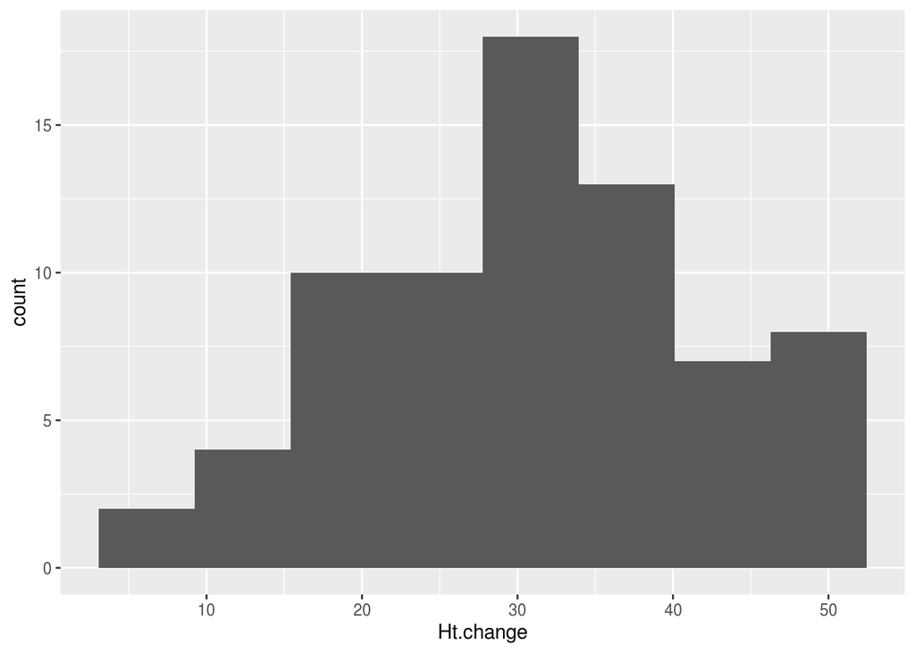

```r
library(ggplot2)
ggplot(data = Spruce, mapping = aes(x = Ht.change)) +
  geom_histogram(bins = 8)
```

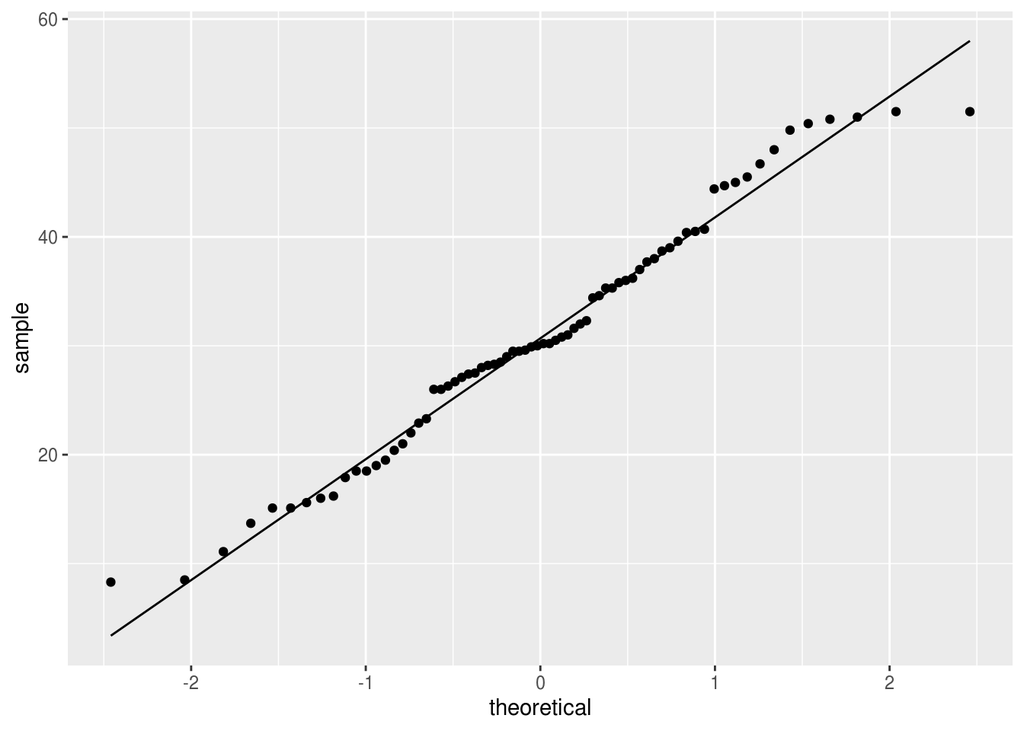

```r
ggplot(data = Spruce, aes(sample = Ht.change)) +
  geom_qq() + geom_qq_line()
```

**The distribution looks approximately normal.**

3. Create a boxplot to compare the distribution of the change in diameters of the seedlings (`Di.change`) grouped by whether or not they were in fertilized plots. Describe the graph.

> Solution:

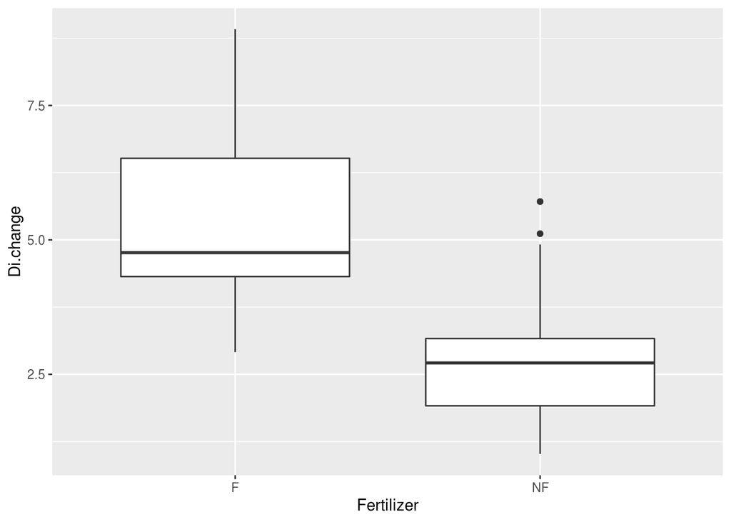

```r
ggplot(data = Spruce, aes(x = Fertilizer, y = Di.change)) +
    geom_boxplot()
```

**Fertilized seeds have a greater average diameter change than non-fertilized seeds. Fertilized seeds have a greater variability in diameter change than non-fertilized seeds.**

4. Use Data Wrangling via `dplyr` to find the numeric summaries of the diameter changes for the two levels fertilization.

> Solution:

```r
library(dplyr)
library(knitr)

df <- Spruce %>%
  group_by(Fertilizer) %>%
  summarize(min(Di.change), mean(Di.change), median(Di.change), max(Di.change), IQR(Di.change), sd(Di.change))

kable(df)
```

| Fertilizer | min(Di.change) | mean(Di.change) | median(Di.change) | max(Di.change) | IQR(Di.change) | sd(Di.change) |
| --- | --- | --- | --- | --- | --- | --- |
| F | 2.91250 | 5.273741 | 4.762500 | 8.91875 | 2.199609 | 1.382824 |
| NF | 1.01875 | 2.717839 | 2.711719 | 5.71250 | 1.249609 | 1.100560 |

5. Use `ggplot` to create a scatter plot of the height changes against the diameter changes, describe the relationship.

> Solution:

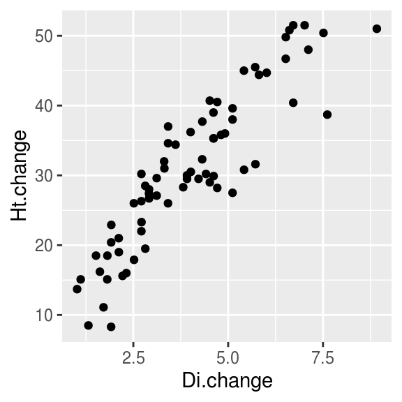

```r
ggplot(data = Spruce, mapping = aes(x = Di.change, y = Ht.change)) +
    geom_point()
```

**As the change in diameter increases, the change in height increases.**